# Credit defaults and the bootstrap approach

### Questions

1. You are interested in the probability of a credit default.

Choose a statistical model $(S, P_{\theta})$ for the random experiment of a credit default. The unknown population parameter $\theta$ should be the probability of a credit default. Use the observations contained in the variable default to compute a point estimate for the probability of a credit default.

2. You are now interested in the sampling distribution of your point estimator for the probability of credit default.

To approximate this sampling distribution, create a bootstrap distribution of your point estimator. Then, visualize it by drawing a histogram of the resampled point estimates. Use 1000 resamples to generate the bootstrap distribution. Use the 1000 resampled point estimatoes from i. to compute an estimate for the standard error of your point estimator.

You realize that the probability of credit default varies among individuals in the population. People with different characteristics have varying probabilities of defaulting on credit. Therefore, you decide to use a logistic regression model to parametrize the probability of a credit default in the following way.

3. Use the functions initial_split(), training() and testing() from tidymodels to split the sample into a 90% training and 10% test set. Make sure to set the seed equal to 123.

Apply a forward stepwise selection algorithm. Fit a logistic regression model using only an intercept to predict default to the training set. Use this model as a null model in the forward stepwise selection algorithm. Define the scope as a formula including income, balance, student, and all possible pairwise interaction terms. Save the selected model as credit_fit.

Write out the form of the fitted model and give an interpretation of one of the estimated slopes.

Calculate the confusion matrix, sensitivity, and specificity for the predicted default values obtained by applying credit_fit to the test observations. Use a threshold of 0.5 to classify the predicted probabilities.

4. Plot the ROC curve for the model credit_fit applied to the test set.

Use the pROC::coords() function to find the optimal threshold based on Youden’s J statistic for the credit_fit model. Compare the resulting sensitivity and specificity values with those from the previous exercise.

The remaining exercises focus on bootstrap resampling in a general context and do not refer to any specific data example. Suppose you have collected sample observations $x = (x_{1}, \ldots, x_{n})^{T}$. Let $x^{1} = (x^{1}_{1}, \ldots, x^{1}_{n})^{T}$ represent the first resample obtained by applying the bootstrap algorithm.

1. What is the probability that the first bootstrap observation $x^{1}_{1}$ is not the j-th observation $x_{j}$ from the original sample? Explain your calculations.
2. What is the probability that the second bootstrap observation $x^{1}_{2}$ is not the j-th observation $x_{j}$ from the original sample? Explain your calculations.
6. Argue that $P(A^{c}_{j}) = \left(1 - \tfrac{1}{n}\right)^{n} \quad \text{where } A_{j}$ is the event that the j-th observation is part of the bootstrap sample.
7. Compute for n $\in \{5,100,10000\}$ the probability that the j-th observation is included in the bootstrap sample $x^{1}$?

#### Packages

We will use functions from the `tidyverse` and `tidymodels`.

You will have to use the `step()` function from the `stats` package in one of the exercises. Since the `tidymodels` package includes a function named `step()`, which serves a different purpose, loading `tidymodels` will create a conflict with the `step()` function from the `stats` package. You therefore have to use the notation `stats::step()` to make sure that you use the correct step function.

In addition, you will need the packages `infer` and `pROC`.

```r
library(tidyverse)
library(tidymodels)
library(infer)
library(pROC)
```

## Solutions

### Credit default data

- `default`: A variable indicating customer default status: TRUE or FALSE.
- `student`: A factor with values “No” and “Yes” indicating whether the customer is a student.
- `balance`: The average remaining credit card balance after monthly payment.
- `income`: Customer income.

Save the Quarto template in a folder and create a subfolder named “data” within that folder. Save the CSV file in the subfolder and then use the following command to read the data.

```r
credit <- read_csv("data/credit_default_data.csv")
```

*Solution 1*.

1. The random experiment of a credit default is modeled as a sequence of independent and identically distributed Bernoulli trials. Hence, the statistical model is given by

$$(\{0, 1\}^n, \mathbb{P}_\theta) \quad \text{with} \quad
\mathbb{P}_\theta(\text{customer defaults in the } i\text{-th trial}) = \mathbb{P}_\theta(X_i = 1) = \theta$$

2. The point estimate for $\theta$ is 0.0333 since $\hat{\theta} = \bar{X} = \frac{1}{n}\sum_i X_i$ is the MLE.

```r
credit |>
   summarize(prob_default = mean(default == TRUE))
```

```
# A tibble: 1 × 1
  prob_default
         <dbl>
1       0.0333
```

*Solution 2*.

1. The bootstrap distribution

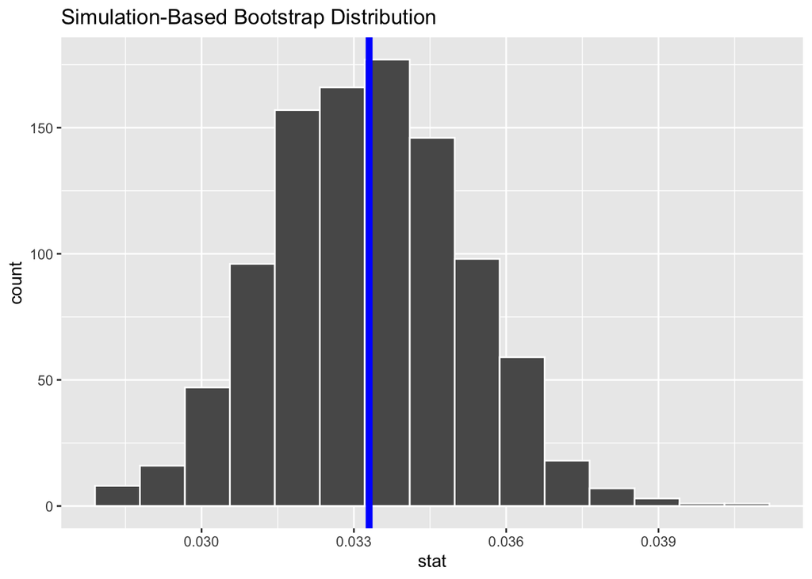

```r
set.seed(12345)

x_sp <- credit |>
  specify(response=default, success = "TRUE")

bootstrap_means <- x_sp |>
  generate(reps = 1000, type = "bootstrap") |>
  calculate(stat = "prop")

visualize(bootstrap_means) +
  geom_vline(xintercept = mean(credit$default == "TRUE"), color = "blue",
linewidth = 2)
```

2. The standard error of the point estimator is 0.0019

```r
bootstrap_means |>
  summarize(se = sd(stat))
```

```
# A tibble: 1 × 1
       se
    <dbl>
1 0.00189
```

**Note**

In the remaining exercises about the credit default data, you want / have to take all variables contained in `credit` into account.

*Solution 3*.

1. Create the training and test set.

```r
set.seed(123)
credit_split <- initial_split(credit, prop=0.9)
train <- training(credit_split)
test <- testing(credit_split)
```

2. Applying the forward step-wise selection algorithm leads to the best model which includes only balance and student.

```r
null_model <- glm(default ~ 1, data = train, family = binomial)

scope_formula <- default ~ (income + balance + student)^2

credit_fit <- stats::step(
  object = null_model,
  scope = scope_formula,
  direction = "forward")
```

```
Start:  AIC=2666.19
default ~ 1

          Df Deviance    AIC
+ balance  1   1442.1 1446.1
+ student  1   2650.8 2654.8
+ income   1   2660.0 2664.0
<none>         2664.2 2666.2

Step:  AIC=1446.11
default ~ balance

          Df Deviance    AIC
+ student  1   1419.5 1425.5
+ income   1   1424.8 1430.8
<none>         1442.1 1446.1

Step:  AIC=1425.47
default ~ balance + student

                  Df Deviance    AIC
<none>                 1419.5 1425.5
+ balance:student  1   1418.3 1426.3
+ income           1   1419.1 1427.1
```

3. The fitted model has the form: default ~ balance + student

```r
summary(credit_fit)
```

```
Call:
glm(formula = default ~ balance + student, family = binomial,
    data = train)

Coefficients:
              Estimate Std. Error z value Pr(>|z|)
(Intercept) -1.086e+01  3.930e-01 -27.630  < 2e-16 ***
balance      5.810e-03  2.467e-04  23.553  < 2e-16 ***
studentYes  -7.188e-01  1.551e-01  -4.633  3.6e-06 ***
---
Signif. codes:  0 '***' 0.001 '**' 0.01 '*' 0.05 '.' 0.1 ' ' 1

(Dispersion parameter for binomial family taken to be 1)

    Null deviance: 2664.2  on 8999  degrees of freedom
Residual deviance: 1419.5  on 8997  degrees of freedom
AIC: 1425.5

Number of Fisher Scoring iterations: 8
```

*Interpretation:*

Being a student (compared to not being a student) decreases the log-odds of default by 0.7188, holding balance constant. In odds ratio terms: $e^{-0.7188} \approx 0.487$; thus, students have about 51.3% lower odds of defaulting than non-students, controlling for balance.

4. The confusion matrix is given by

```r
pred_default <- predict(credit_fit, newdata = test, type = "response")

test_pred <- ifelse(pred_default > 0.5, TRUE, FALSE)

conf_mat <- table(Predicted = test_pred, Actual = test$default)

conf_mat
```

```
         Actual
Predicted FALSE TRUE
    FALSE   968   20
    TRUE      4    8
```

From the confusion matrix one can compute the sensitivity, and specificity values

```r
sensitivity <- conf_mat["TRUE", "TRUE"] / sum(conf_mat[, "TRUE"])
specificity <- conf_mat["FALSE", "FALSE"] / sum(conf_mat[, "FALSE"])

performance <- tibble(
  threshold = 0.5,
  sensitivity,
  specificity
)

performance
```

```
# A tibble: 1 × 3
  threshold sensitivity specificity
      <dbl>       <dbl>       <dbl>
1       0.5       0.286       0.996
```

*Solution 4*.

1. The ROC curve is shown in the following plot

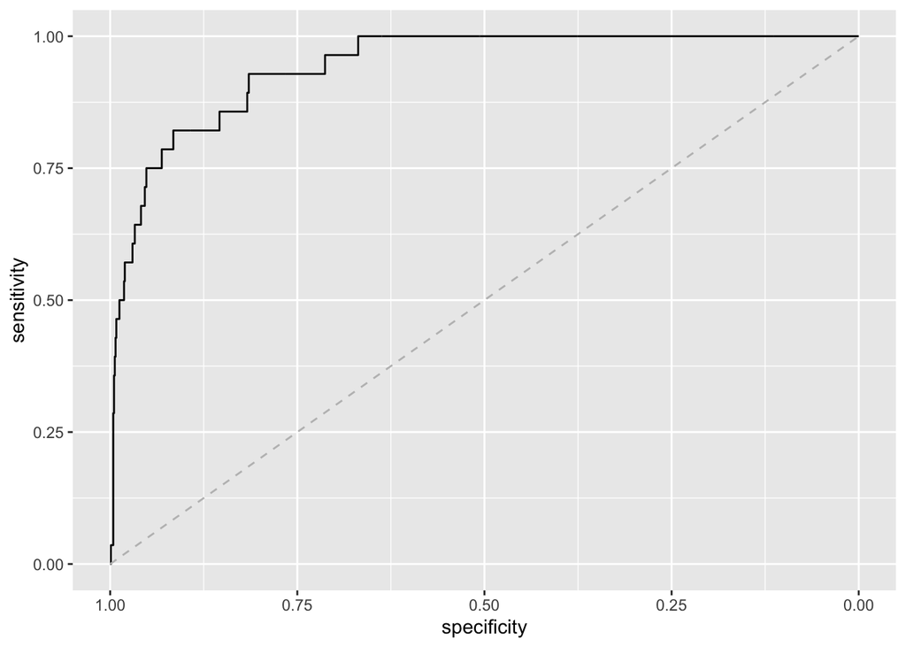

```r
credit_roc <- suppressMessages(
  roc(test$default, pred_default)
)

ggroc(credit_roc) +
  annotate("segment", x = 1, xend = 0, y = 0, yend = 1,
           color = "grey", linetype = "dashed")
```

2. Using `coords()` gives the following values

```r
opt_coords <- coords(credit_roc, "best", best.method = "youden", ret = c("threshold", "sensitivity", "specificity"))

opt_coords
```

```
   threshold sensitivity specificity
1 0.01648004   0.9285714   0.8148148
```

Using the ROC-optimized threshold of 0.0165 leads to a much better balance between sensitivity and specificity. The model becomes substantially better at detecting defaulters while still maintaining high specificity.

### Bootstrap

*Solution 5*.

1. The probability is equal to
   $${P}(x_1^1 \ne x_j) = 1 - \frac{1}{n}$$
   due to each bootstrap draw being an independent random sample from the original n observations, each with probability $\frac{1}{n}$
2. The probability is equal to
   $${P}(x_2^1 \ne x_j) = 1 - \frac{1}{n}$$
   since the second draw is also independent and identically distributed.

*Solution 7*. The probabilities are computed using R:

```r
n_values <- c(5, 100, 10000)

calculate_probs <- function(n) {
  1 - (1 - 1/n)^n
}

prob_values <- sapply(n_values, calculate_probs)

data.frame(
  n = n_values,
  prob = prob_values
)
```

```
      n      prob
1     5 0.6723200
2   100 0.6339677
3 10000 0.6321390
```

*Solution 8*.

```r
set.seed(123)
x_indices <- 1:100
j <- sample(x_indices, 1) # choose j
j_included <- replicate(
  10000, # number of replications
  sum(
    # compare bootstrap values with j
    sample(x_indices, 100, replace = TRUE) == j
    )
  # check if j is included at least once
  > 0)
# proportion of times j is included in the resample
mean(j_included)
```

```
[1] 0.6384
```

The simulation results closely match the theoretical probabilities. For considering the case $n\rightarrow \infty$ observe that the probability that a specific observation is included in a bootstrap sample of size n converges to about 63.2% as n grows large, rather than going to zero. This reflects the inherent property of bootstrap sampling with replacement, where each observation has a consistent chance of being selected at least once regardless of sample size.